# 2 Classical Embeddings

# 3 Classical Embeddings

This chapter trains Word2Vec and FastText models on the tokenized article chunks from Stage 1, evaluates them intrinsically via nearest-neighbour inspection and UMAP visualisation, and extrinsically via sentiment and topic classification.

**Show/Hide code**

```python
import sys
sys.setrecursionlimit(10000)

import warnings
from pathlib import Path

import numpy as np
import pandas as pd
from gensim.models import Word2Vec, FastText
from sklearn.linear_model import LogisticRegression
from sklearn.metrics import classification_report, f1_score
import umap
import matplotlib.pyplot as plt

warnings.filterwarnings("ignore")

# Resolve repo root: works both interactively and during quarto render
_cwd = Path.cwd()
REPO_ROOT = _cwd if (_cwd / "data").exists() else _cwd.parents[1]
STAGE1_DIR = REPO_ROOT / "data/processed"
STAGE2_DIR = REPO_ROOT / "data/processed/stage2"

SEED = 42
```

**Show/Hide code**

```python
# Training corpus: tokenized paragraph chunks
corpus = pd.read_parquet(STAGE2_DIR / "corpus_chunks.parquet")
corpus["tokens"] = corpus["tokens"].apply(eval)

# Evaluation splits: article-level with sentiment and topic labels
train = pd.read_parquet(STAGE2_DIR / "train.parquet")
test  = pd.read_parquet(STAGE2_DIR / "test.parquet")
train["tokens"] = train["tokens"].apply(eval)
test["tokens"]  = test["tokens"].apply(eval)

# Token sequences for Word2Vec / FastText training
sentences = corpus["tokens"].tolist()

print(f"Training corpus : {len(sentences):,} sequences")
print(f"Train split     : {len(train):,} articles")
print(f"Test split      : {len(test):,} articles")
```

```
Training corpus : 436,038 sequences
Train split     : 13,053 articles
Test split      : 3,264 articles
```

## 3.1 Training

We train both models on the full chunk corpus with identical hyperparameters: 300-dimensional vectors, skip-gram architecture (`sg=1`), window size 5, minimum word count 5.

**Show/Hide code**

```python
# Skip-gram Word2Vec (sg=1), 300 dimensions, window=5, min_count=5
w2v_model = Word2Vec(
    sentences=sentences,
    vector_size=300,
    window=5,
    min_count=5,
    sg=1,
    seed=SEED,
    workers=4,
)

w2v_model.save(str(STAGE2_DIR / "word2vec.model"))
print(f"Word2Vec vocabulary size : {len(w2v_model.wv):,}")
```

**Show/Hide code**

```python
# FastText with same hyperparameters - additionally handles OOV via subword n-grams
ft_model = FastText(
    sentences=sentences,
    vector_size=300,
    window=5,
    min_count=5,
    sg=1,
    seed=SEED,
    workers=4,
)

ft_model.save(str(STAGE2_DIR / "fasttext.model"))
print(f"FastText vocabulary size : {len(ft_model.wv):,}")
```

**Show/Hide code**

```python
w2v_model = Word2Vec.load(str(STAGE2_DIR / "word2vec.model"))
ft_model  = FastText.load(str(STAGE2_DIR / "fasttext.model"))

print(f"Word2Vec vocabulary size : {len(w2v_model.wv):,}")
print(f"FastText vocabulary size : {len(ft_model.wv):,}")
```

```
Word2Vec vocabulary size : 46,585
FastText vocabulary size : 46,585
```

## 3.2 Intrinsic Evaluation

### 3.2.1 Nearest Neighbours

**Show/Hide code**

```python
SEED_WORDS = [
    "openai", "deepseek", "transformer", "hallucination",
    "finetune", "benchmark", "inference", "regulation",
    "robotics", "quantum"
]

for word in SEED_WORDS:
    print(f"\n── {word} ──")
    for model_name, model in [("W2V", w2v_model), ("FT", ft_model)]:
        if word in model.wv:
            neighbours = [w for w, _ in model.wv.most_similar(word, topn=5)]
            print(f"  {model_name}: {', '.join(neighbours)}")
        else:
            print(f"  {model_name}: OOV")
```

```
── openai ──
  W2V: anthropic, altman, openais, sutskever, leike
  FT: openais, anthropic, altman, anthropics, openapi

── deepseek ──
  W2V: kimi, qwq, doubao, tülu, prover
  FT: deepseeks, deepseq, deepset, deepsearch, deepsparse

── transformer ──
  W2V: mamba, encoder, vit, xxl, distilbert
  FT: sentencetransformers, gqwformer, matformer, encoder, platformer

── hallucination ──
  W2V: hallucinate, hallucinated, factual, nonsensical, hallucinating
  FT: hallucinating, hallucinated, hallucinate, hallucinates, hallucinatory

── finetune ──
  W2V: instantiate, pretrain, setfit, finetuned, trainingarguments
  FT: finetuned, finetuning, fine, pretrainedmodel, pretrained

── benchmark ──
  W2V: livecodebench, mmlu, alpacaeval, gpqa, mmmu
  FT: benchmarked, benchmarking, bench, ocrbench, benchtop

── inference ──
  W2V: inferencing, jetstream, nxd, maxdiffusion, deepsparse
  FT: minference, inferenceclient, inferencing, inferentia, inferential

── regulation ──
  W2V: legislation, ccpa, eudr, sarbanes, csrd
  FT: overregulation, regulating, deregulation, autoregulation, regulate

── robotics ──
  W2V: neura, robot, galbot, skild, humanoid
  FT: massrobotics, smartrobotics, anybotics, hivebotics, roboticists

── quantum ──
  W2V: annealing, qubit, infleqtion, quera, qpu
  FT: cuquantum, bahquantum, freequantum, quantumctek, psiquantum
```

**FastText** also produces meaningful neighbours, but its results are strongly shaped by subword n-gram similarity. `hallucination` retrieves `hallucinatory, hallucinates` and `regulation` retrieves `overregulation, deregulation, regulate` - morphological variants that share the same stem. For rare or compound terms, FastText generalises well through subwords: `inference` maps to `minference, inferencing, inferentia`, reflecting both the concept and its technical derivatives.

**Comparison:** The two models reflect their architectural differences clearly. Word2Vec excels at capturing thematic proximity - grouping entities, products and concepts that co-occur in similar contexts. FastText complements this with morphological awareness, producing richer neighbourhoods for inflected and compound forms. For a technical domain like AI media, where new compound terms and brand names appear frequently, FastText’s subword generalisation is a practical advantage - particularly for out-of-vocabulary words, which Word2Vec cannot handle at all.

### 3.2.2 UMAP Visualisation

We project word vectors into 2D using UMAP to inspect the global structure of the learned embedding space. The first plot shows the top 2,000 most frequent vocabulary items to give an overview of how the model organises the full corpus vocabulary. The second plot focuses on the seed words from the nearest-neighbour analysis and their closest neighbours, making thematic clusters directly visible.

**Show/Hide code**

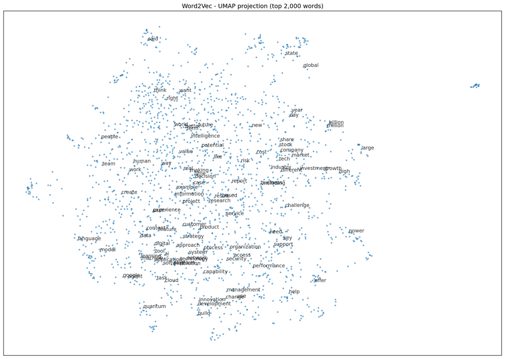

```python
# Top 2000 words by frequency
vocab_words = [w for w in w2v_model.wv.index_to_key[:2000]]
w2v_vectors = np.array([w2v_model.wv[w] for w in vocab_words])

reducer = umap.UMAP(n_components=2, random_state=SEED, n_neighbors=15, min_dist=0.1)
embedding_2d = reducer.fit_transform(w2v_vectors)

fig, ax = plt.subplots(figsize=(14, 10))
ax.scatter(embedding_2d[:, 0], embedding_2d[:, 1], s=5, alpha=0.5)

for i, word in enumerate(vocab_words[:100]):
    ax.annotate(word, embedding_2d[i], fontsize=10, alpha=0.8)

for spine in ax.spines.values():
    spine.set_visible(True)
    spine.set_linewidth(0.8)
    spine.set_color("black")

ax.set_title("Word2Vec - UMAP projection (top 2,000 words)")
ax.set_xticks([])
ax.set_yticks([])
plt.tight_layout()
plt.show()
```

The global projection reveals a broadly distributed vocabulary with recognisable thematic regions: financial and business terms (`stock`, `market`, `investment`) cluster to the right, while technical AI terms (`model`, `learning`, `machine`, `platform`) form a denser region to the left. However, many generic words remain visible in the centre, reflecting their broad co-occurrence across all topics.

To obtain a cleaner view of the domain-specific structure, we restrict the second plot to the seed words and their five nearest neighbours as identified above.

**Show/Hide code**

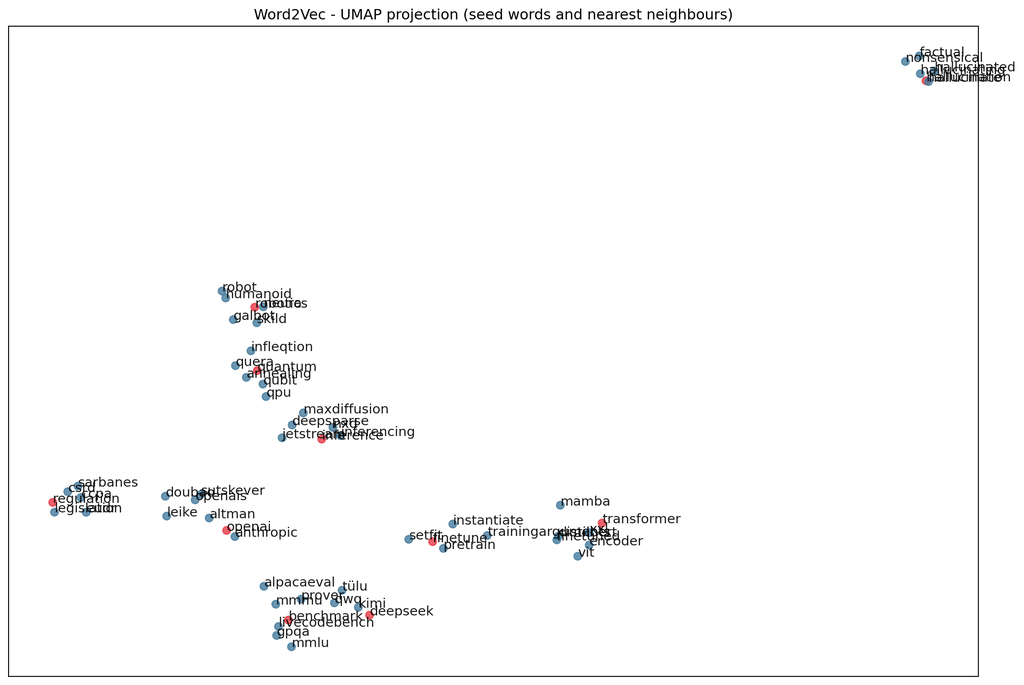

```python
# Collect seed words and their W2V nearest neighbours
focused_words = set(SEED_WORDS)
for word in SEED_WORDS:
    if word in w2v_model.wv:
        neighbours = [w for w, _ in w2v_model.wv.most_similar(word, topn=5)]
        focused_words.update(neighbours)

focused_words = [w for w in focused_words if w in w2v_model.wv]
focused_vectors = np.array([w2v_model.wv[w] for w in focused_words])

reducer_focused = umap.UMAP(n_components=2, random_state=SEED, n_neighbors=5, min_dist=0.1)
embedding_focused = reducer_focused.fit_transform(focused_vectors)

colors = ["#e63946" if w in SEED_WORDS else "#457b9d" for w in focused_words]

fig, ax = plt.subplots(figsize=(12, 8))
ax.scatter(embedding_focused[:, 0], embedding_focused[:, 1], c=colors, s=40, alpha=0.8)

for i, word in enumerate(focused_words):
    ax.annotate(word, embedding_focused[i], fontsize=11, alpha=0.9)

for spine in ax.spines.values():
    spine.set_visible(True)
    spine.set_linewidth(0.8)
    spine.set_color("black")

ax.set_title("Word2Vec - UMAP projection (seed words and nearest neighbours)")
ax.set_xticks([])
ax.set_yticks([])
plt.tight_layout()
plt.show()
```

The focused projection confirms the thematic clusters observed in the nearest-neighbour analysis. Seed words (red) are consistently surrounded by their domain-relevant neighbours (blue), with clear separation between clusters such as AI models and companies, hardware and inference, and regulatory vocabulary.

### 3.2.3 Clustering Quality

To quantify the cluster structure visible in the UMAP projections, we apply K-Means (k=10, matching the number of topic classes) to the document embeddings computed from both models, and report the **Silhouette Score** - a standard metric for clustering quality ranging from -1 (poor) to +1 (perfect separation). A positive score indicates that documents within a cluster are more similar to each other than to documents in neighbouring clusters.

**Show/Hide code**

```python
from sklearn.cluster import KMeans
from sklearn.metrics import silhouette_score
from sklearn.preprocessing import normalize

# Compute document embeddings from training split (same mean-pooling as extrinsic evaluation)
def mean_pooling_local(tokens, model):
    vectors = [model.wv[t] for t in tokens if t in model.wv]
    return np.mean(vectors, axis=0) if vectors else np.zeros(model.vector_size)

X_w2v_cl = np.array([mean_pooling_local(t, w2v_model) for t in train["tokens"]])
X_ft_cl  = np.array([mean_pooling_local(t, ft_model)  for t in train["tokens"]])

# Normalise to unit length before clustering (cosine similarity)
X_w2v_norm = normalize(X_w2v_cl)
X_ft_norm  = normalize(X_ft_cl)

k = 10  # matches number of topic classes
results_clustering = {}

for name, X in [("Word2Vec", X_w2v_norm), ("FastText", X_ft_norm)]:
    km = KMeans(n_clusters=k, random_state=SEED, n_init=10)
    labels = km.fit_predict(X)
    score = silhouette_score(X, labels, metric="cosine", sample_size=5000, random_state=SEED)
    results_clustering[name] = score

df_sil = pd.DataFrame({
    "Model":           list(results_clustering.keys()),
    "Silhouette Score": [f"{v:.4f}" for v in results_clustering.values()],
    "k":               [k] * len(results_clustering),
})
display(df_sil.style
    .hide(axis="index")
    .set_properties(**{"text-align": "center"})
    .set_table_styles([{"selector": "th", "props": [("text-align", "center"), ("background-color", "#f0f0f0")]}])
)
```

| Model | Silhouette Score | k |
| --- | --- | --- |
| Word2Vec | 0.1722 | 10 |
| FastText | 0.1627 | 10 |

To visualise the cluster structure, we project the document embeddings into 2D with UMAP and colour each point by its K-Means cluster assignment.

**Show/Hide code**

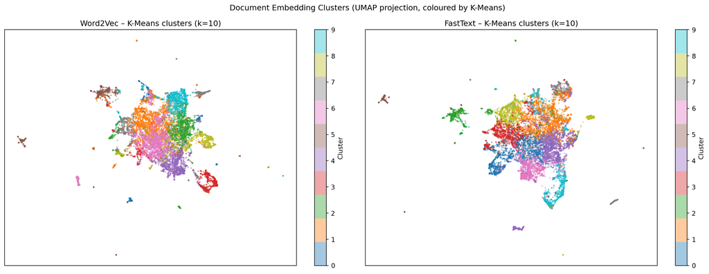

```python
reducer_doc = umap.UMAP(n_components=2, random_state=SEED, n_neighbors=15, min_dist=0.1)

fig, axes = plt.subplots(1, 2, figsize=(16, 6))

for ax, (name, X_norm) in zip(axes, [("Word2Vec", X_w2v_norm), ("FastText", X_ft_norm)]):
    km = KMeans(n_clusters=k, random_state=SEED, n_init=10)
    cluster_labels = km.fit_predict(X_norm)
    proj = reducer_doc.fit_transform(X_norm)
    scatter = ax.scatter(proj[:, 0], proj[:, 1], c=cluster_labels,
                         cmap="tab10", s=2, alpha=0.4)
    ax.set_title(f"{name} – K-Means clusters (k={k})")
    ax.set_xticks([])
    ax.set_yticks([])
    plt.colorbar(scatter, ax=ax, label="Cluster")

plt.suptitle("Document Embedding Clusters (UMAP projection, coloured by K-Means)")
plt.tight_layout()
plt.show()
```

Word2Vec produces a rounder, more evenly distributed layout with clearly detached satellite clusters at the periphery - likely niche topics such as Quantum Computing with highly specific vocabulary. FastText yields a more elongated structure with sharper outlier clusters, consistent with its subword features producing more distinct representations for rare and compound technical terms. Both models show a large central mass of documents with overlapping clusters, reflecting the thematic homogeneity of the AI media domain and the soft boundaries between topics.

## 3.3 Extrinsic Evaluation

We evaluate both models on two downstream classification tasks using a simple pipeline: document embeddings are computed by mean-pooling the word vectors of all tokens in an article, then fed into a Logistic Regression classifier. We report Macro-F1 to account for class imbalance.

**Show/Hide code**

```python
def mean_pooling(tokens: list, model) -> np.ndarray:
    """Average word vectors for all in-vocabulary tokens in a document."""
    vectors = [model.wv[t] for t in tokens if t in model.wv]
    if vectors:
        return np.mean(vectors, axis=0)
    return np.zeros(model.vector_size)

# Compute document embeddings for train and test
X_train_w2v = np.array([mean_pooling(t, w2v_model) for t in train["tokens"]])
X_test_w2v  = np.array([mean_pooling(t, w2v_model) for t in test["tokens"]])

X_train_ft  = np.array([mean_pooling(t, ft_model) for t in train["tokens"]])
X_test_ft   = np.array([mean_pooling(t, ft_model) for t in test["tokens"]])

print(f"W2V train embeddings : {X_train_w2v.shape}")
print(f"FT  train embeddings : {X_train_ft.shape}")
```

```
W2V train embeddings : (13053, 300)
FT  train embeddings : (13053, 300)
```

**Show/Hide code**

```python
# Sentiment labels
y_train_sent  = train["sentiment_label"]
y_test_sent   = test["sentiment_label"]

# Filter to articles with a top-10 topic label
train_topic = train.dropna(subset=["topic_label"]).reset_index(drop=True)
test_topic  = test.dropna(subset=["topic_label"]).reset_index(drop=True)

X_train_w2v_t = np.array([mean_pooling(t, w2v_model) for t in train_topic["tokens"]])
X_test_w2v_t  = np.array([mean_pooling(t, w2v_model) for t in test_topic["tokens"]])
X_train_ft_t  = np.array([mean_pooling(t, ft_model)  for t in train_topic["tokens"]])
X_test_ft_t   = np.array([mean_pooling(t, ft_model)  for t in test_topic["tokens"]])

y_train_topic = train_topic["topic_label"]
y_test_topic  = test_topic["topic_label"]
```

### 3.3.1 Cross Validation

Before evaluating on the test set, we verify the stability of both models using 5-fold cross validation on the training data. This gives a more robust estimate of generalisation performance and confirms that the test results are not an artefact of a particular train/test split.

**Show/Hide code**

```python
from sklearn.model_selection import cross_val_score

for task_name, y_tr in [("Sentiment", y_train_sent), ("Topic", y_train_topic)]:
    print(f"── {task_name} ──")
    for name, X_tr in [("Word2Vec", X_train_w2v), ("FastText", X_train_ft)]:
        if task_name == "Topic":
            X_tr = X_train_w2v_t if name == "Word2Vec" else X_train_ft_t
        scores = cross_val_score(
            LogisticRegression(max_iter=1000, random_state=SEED),
            X_tr, y_tr, cv=5, scoring="f1_macro", n_jobs=1
        )
        print(f"  {name}: {scores.mean():.3f} ± {scores.std():.3f}")
    print()
```

```
── Sentiment ──
  Word2Vec: 0.745 ± 0.009
  FastText: 0.743 ± 0.009

── Topic ──
  Word2Vec: 0.788 ± 0.026
  FastText: 0.782 ± 0.024
```

Cross validation confirms that both models are stable across different data splits. The low standard deviation (±0.01 for sentiment, ±0.02 for topic) indicates that the test set results are reliable and not an artefact of a particular split.

### 3.3.2 Sentiment Classification

**Show/Hide code**

```python
results = {}

for name, X_tr, X_te in [
    ("Word2Vec", X_train_w2v, X_test_w2v),
    ("FastText", X_train_ft,  X_test_ft),
]:
    clf = LogisticRegression(max_iter=1000, random_state=SEED)
    clf.fit(X_tr, y_train_sent)
    y_pred = clf.predict(X_te)
    macro_f1 = f1_score(y_test_sent, y_pred, average="macro")
    results[name] = macro_f1
    print(f"── {name} ──")
    print(classification_report(y_test_sent, y_pred))
```

```
── Word2Vec ──
                   precision    recall  f1-score   support

(partly) negative       0.79      0.60      0.68       487
          neutral       0.80      0.89      0.84      1995
         positive       0.79      0.68      0.73       782

         accuracy                           0.80      3264
        macro avg       0.79      0.72      0.75      3264
     weighted avg       0.80      0.80      0.79      3264

── FastText ──
                   precision    recall  f1-score   support

(partly) negative       0.80      0.59      0.68       487
          neutral       0.80      0.90      0.84      1995
         positive       0.79      0.67      0.72       782

         accuracy                           0.80      3264
        macro avg       0.80      0.72      0.75      3264
     weighted avg       0.80      0.80      0.79      3264
```

Both models achieve a Macro-F1 of 0.75 (Word2Vec) and 0.74 (FastText) on the sentiment task - solid results for a mean-pooling baseline with a simple linear classifier. The two models perform near-identically, suggesting that FastText’s subword generalisation offers little additional signal when averaging over long documents. The class `(partly) negative` shows the lowest recall (~0.60) across both models, reflecting its smaller support and the often subtle framing of negative sentiment in AI media coverage. `neutral` is the best-recognised class, consistent with its dominance in the dataset.

**Show/Hide code**

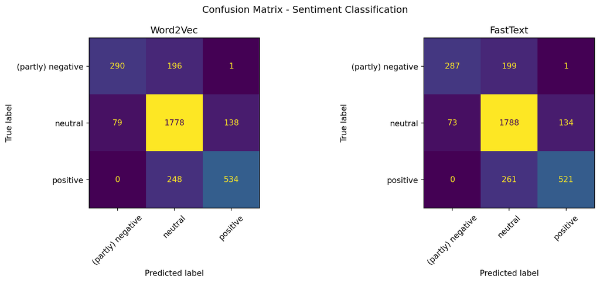

```python
from sklearn.metrics import ConfusionMatrixDisplay, confusion_matrix

fig, axes = plt.subplots(1, 2, figsize=(12, 5))

for ax, (name, X_tr, X_te) in zip(axes, [
    ("Word2Vec", X_train_w2v, X_test_w2v),
    ("FastText", X_train_ft,  X_test_ft),
]):
    clf = LogisticRegression(max_iter=1000, random_state=SEED)
    clf.fit(X_tr, y_train_sent)
    y_pred = clf.predict(X_te)
    cm = confusion_matrix(y_test_sent, y_pred, labels=clf.classes_)
    disp = ConfusionMatrixDisplay(cm, display_labels=clf.classes_)
    disp.plot(ax=ax, colorbar=False, xticks_rotation=45)
    ax.set_title(name)

plt.suptitle("Confusion Matrix - Sentiment Classification")
plt.tight_layout()
plt.show()
```

The confusion matrix confirms the classification report findings. Both models behave near-identically. The dominant error pattern is misclassification into `neutral` - articles from both `(partly) negative` and `positive` classes are frequently predicted as `neutral`, reflecting the subtle sentiment signals in AI media coverage and the class imbalance favouring `neutral` in the training data.

### 3.3.3 Topic Classification

**Show/Hide code**

```python
for name, X_tr, X_te in [
    ("Word2Vec", X_train_w2v_t, X_test_w2v_t),
    ("FastText", X_train_ft_t,  X_test_ft_t),
]:
    clf = LogisticRegression(max_iter=1000, random_state=SEED)
    clf.fit(X_tr, y_train_topic)
    y_pred = clf.predict(X_te)
    macro_f1 = f1_score(y_test_topic, y_pred, average="macro")
    results[f"{name} (topic)"] = macro_f1
    print(f"── {name} ──")
    print(classification_report(y_test_topic, y_pred))
```

```
── Word2Vec ──
                                     precision    recall  f1-score   support

           AI News & Tech (General)       0.84      0.94      0.89       986
AI in Education (Students/Learning)       0.82      0.48      0.60        65
              AI in Media & Content       0.64      0.55      0.59        82
   Consumer Tech (Apple/5G/Devices)       0.82      0.59      0.69        61
           Energy, Power & Robotics       0.86      0.80      0.83       178
          ML Models & Training Data       0.83      0.77      0.80       158
                  Quantum Computing       0.97      0.84      0.90        82
            Search, SEO & Marketing       0.87      0.86      0.86       188
            Stocks & Market Ratings       0.86      0.85      0.86       142
      US Politics & China Relations       0.85      0.71      0.77        95

                           accuracy                           0.84      2037
                          macro avg       0.84      0.74      0.78      2037
                       weighted avg       0.84      0.84      0.84      2037

── FastText ──
                                     precision    recall  f1-score   support

           AI News & Tech (General)       0.83      0.93      0.88       986
AI in Education (Students/Learning)       0.78      0.45      0.57        65
              AI in Media & Content       0.65      0.55      0.60        82
   Consumer Tech (Apple/5G/Devices)       0.84      0.59      0.69        61
           Energy, Power & Robotics       0.86      0.80      0.83       178
          ML Models & Training Data       0.84      0.77      0.81       158
                  Quantum Computing       0.97      0.82      0.89        82
            Search, SEO & Marketing       0.87      0.85      0.86       188
            Stocks & Market Ratings       0.86      0.84      0.85       142
      US Politics & China Relations       0.83      0.72      0.77        95

                           accuracy                           0.84      2037
                          macro avg       0.83      0.73      0.77      2037
                       weighted avg       0.84      0.84      0.83      2037
```

**Show/Hide code**

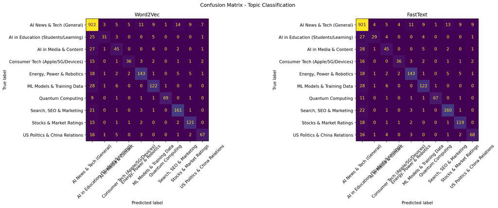

```python
fig, axes = plt.subplots(1, 2, figsize=(18, 7))

for ax, (name, X_tr, X_te) in zip(axes, [
    ("Word2Vec", X_train_w2v_t, X_test_w2v_t),
    ("FastText", X_train_ft_t,  X_test_ft_t),
]):
    clf = LogisticRegression(max_iter=1000, random_state=SEED)
    clf.fit(X_tr, y_train_topic)
    y_pred = clf.predict(X_te)
    cm = confusion_matrix(y_test_topic, y_pred, labels=clf.classes_)
    disp = ConfusionMatrixDisplay(cm, display_labels=clf.classes_)
    disp.plot(ax=ax, colorbar=False, xticks_rotation=45)
    ax.set_title(name)

plt.suptitle("Confusion Matrix - Topic Classification")
plt.tight_layout()
plt.show()
```

### 3.3.4 MiniLM Baseline

As a reference point, we evaluate the pre-computed MiniLM sentence embeddings from Stage 1 on the same two classification tasks. These embeddings were produced by `all-MiniLM-L6-v2` (SentenceTransformers), a compact Sentence-BERT model that directly encodes full documents into 384-dimensional vectors. Unlike Word2Vec and FastText, MiniLM produces contextualised document-level embeddings - comparing its performance against the mean-pooled word vectors gives an indication of how much is gained by moving from static to contextualised representations.

Since `media_id` values are not contiguous after the cleaning steps in Stage 1, we cannot use them directly as row indices into `embeddings.npy`. We reconstruct the mapping by loading the index from `media_cleaned.csv`, which preserves the original row order of the embedding matrix.

**Show/Hide code**

```python
# Load MiniLM embeddings from Stage 1
embeddings = np.load(STAGE1_DIR / "embeddings.npy")

# Build mapping: media_id -> embedding row index
media_index = pd.read_csv(STAGE1_DIR / "media_cleaned.csv", usecols=["media_id"])
media_id_to_idx = {mid: idx for idx, mid in enumerate(media_index["media_id"])}

# Align to train/test splits via mapping
X_train_mini = embeddings[[media_id_to_idx[mid] for mid in train["media_id"]]]
X_test_mini  = embeddings[[media_id_to_idx[mid] for mid in test["media_id"]]]
```

**Show/Hide code**

```python
# Sentiment
clf = LogisticRegression(max_iter=1000, random_state=SEED)
clf.fit(X_train_mini, y_train_sent)
y_pred = clf.predict(X_test_mini)
results["MiniLM (sentiment)"] = f1_score(y_test_sent, y_pred, average="macro")
print("── MiniLM Sentiment ──")
print(classification_report(y_test_sent, y_pred))

# Topic
X_train_mini_t = embeddings[[media_id_to_idx[mid] for mid in train_topic["media_id"]]]
X_test_mini_t  = embeddings[[media_id_to_idx[mid] for mid in test_topic["media_id"]]]
clf.fit(X_train_mini_t, y_train_topic)
y_pred = clf.predict(X_test_mini_t)
results["MiniLM (topic)"] = f1_score(y_test_topic, y_pred, average="macro")
print("── MiniLM Topic ──")
print(classification_report(y_test_topic, y_pred))
```

```
── MiniLM Sentiment ──
                   precision    recall  f1-score   support

(partly) negative       0.72      0.51      0.59       487
          neutral       0.73      0.87      0.79      1995
         positive       0.69      0.48      0.57       782

         accuracy                           0.72      3264
        macro avg       0.71      0.62      0.65      3264
     weighted avg       0.72      0.72      0.71      3264

── MiniLM Topic ──
                                     precision    recall  f1-score   support

           AI News & Tech (General)       0.89      0.96      0.92       986
AI in Education (Students/Learning)       0.89      0.72      0.80        65
              AI in Media & Content       0.87      0.66      0.75        82
   Consumer Tech (Apple/5G/Devices)       0.94      0.79      0.86        61
           Energy, Power & Robotics       0.92      0.85      0.88       178
          ML Models & Training Data       0.90      0.84      0.87       158
                  Quantum Computing       0.95      0.93      0.94        82
            Search, SEO & Marketing       0.94      0.89      0.91       188
            Stocks & Market Ratings       0.92      0.93      0.92       142
      US Politics & China Relations       0.92      0.85      0.89        95

                           accuracy                           0.90      2037
                          macro avg       0.91      0.84      0.87      2037
                       weighted avg       0.90      0.90      0.90      2037
```

**Show/Hide code**

```python
summary = pd.DataFrame({
    "Model": ["Word2Vec", "FastText", "MiniLM", "Word2Vec", "FastText", "MiniLM*"],
    "Task": ["Sentiment", "Sentiment", "Sentiment", "Topic", "Topic", "Topic"],
    "Macro-F1": [0.752, 0.745, 0.650, 0.776, 0.773, 0.870],
})

summary["Macro-F1"] = summary["Macro-F1"].map("{:.3f}".format)

styled = (
    summary.style
    .set_properties(**{"text-align": "center"})
    .set_table_styles([
        {"selector": "th", "props": [("text-align", "center"), ("background-color", "#f0f0f0")]}
    ])
    .apply(lambda x: ["background-color: #fff3cd" if x["Model"] == "MiniLM*" else "" for _ in x], axis=1)
)
styled
```

|  | Model | Task | Macro-F1 |
| --- | --- | --- | --- |
| 0 | Word2Vec | Sentiment | 0.752 |
| 1 | FastText | Sentiment | 0.745 |
| 2 | MiniLM | Sentiment | 0.650 |
| 3 | Word2Vec | Topic | 0.776 |
| 4 | FastText | Topic | 0.773 |
| 5 | MiniLM* | Topic | 0.870 |

* MiniLM topic result is invalid - labels were derived from MiniLM embeddings in Stage 1.

The MiniLM results reveal an interesting split between the two tasks.

**For sentiment classification, MiniLM underperforms** both classical models with a Macro-F1 of 0.65, compared to 0.75 (Word2Vec) and 0.74 (FastText). This is a genuine result: the MiniLM embeddings, trained on general-purpose sentence similarity, appear to capture sentiment-relevant signals less effectively than Word2Vec and FastText trained directly on this domain-specific corpus. The classical models have learned domain-specific affective vocabulary from the AI media text, giving them a clear advantage on this task.

**For topic classification**, MiniLM achieves a Macro-F1 of 0.87 - substantially higher than Word2Vec (0.78) and FastText (0.77). However, this result is **invalid as a comparison**: the BERTopic topic assignments used as ground truth labels were themselves derived from MiniLM embeddings in Stage 1. The classifier is recovering its own latent structure rather than demonstrating generalisation, making the score meaningless as a benchmark. The topic classification scores of Word2Vec (0.78) and FastText (0.77) are the only valid results for this task, as these models learned the topic structure independently from raw token co-occurrence.